# Partie 5 : Comparaison des Classifieurs et Conclusion

Compléments de Mathématiques 2 – Introduction au Machine Learning

Auteur·rice·s

HAMLIL Mohamed

PARDO TERAN German

EL KORAICHI Mohamed Yassine

ANZID Keltoum

Date de publication

2 mars 2026

# Chargement des résultats

```r
model_logistic <- readRDS(here::here("output", "model_logistic.rds"))
model_rf <- readRDS(here::here("output", "model_rf.rds"))
cm_logistic <- readRDS(here::here("output", "cm_logistic.rds"))
cm_rf <- readRDS(here::here("output", "cm_rf.rds"))
roc_logistic <- readRDS(here::here("output", "roc_logistic.rds"))
roc_rf <- readRDS(here::here("output", "roc_rf.rds"))
cat("Tous les résultats chargés.\n")
```

```
Tous les résultats chargés.
```

# Comparaison des classifieurs

## Tableau récapitulatif

```r
results_df <- data.frame(
  Modèle = c("Régression Logistique", "Forêt Aléatoire"),
  AUC_CV = c(round(max(model_logistic$results$ROC), 4),
             round(max(model_rf$results$ROC), 4)),
  AUC_Test = c(round(auc(roc_logistic), 4),
               round(auc(roc_rf), 4)),
  Accuracy = c(round(cm_logistic$overall["Accuracy"], 4),
               round(cm_rf$overall["Accuracy"], 4)),
  Sensibilité = c(round(cm_logistic$byClass["Sensitivity"], 4),
                  round(cm_rf$byClass["Sensitivity"], 4)),
  Spécificité = c(round(cm_logistic$byClass["Specificity"], 4),
                  round(cm_rf$byClass["Specificity"], 4)),
  F1 = c(round(cm_logistic$byClass["F1"], 4),
         round(cm_rf$byClass["F1"], 4))
)

kable(results_df, booktabs = TRUE)
```

Table 1: Comparaison des performances des classifieurs

| Modèle | AUC_CV | AUC_Test | Accuracy | Sensibilité | Spécificité | F1 |
| --- | --- | --- | --- | --- | --- | --- |
| Régression Logistique | 0.7319 | 0.7337 | 0.6749 | 0.7802 | 0.5496 | 0.7229 |
| Forêt Aléatoire | 0.7483 | 0.7566 | 0.7007 | 0.7746 | 0.6125 | 0.7378 |

Le Table 1 résume les performances des deux classifieurs sur le jeu de test.

## Courbes ROC comparées

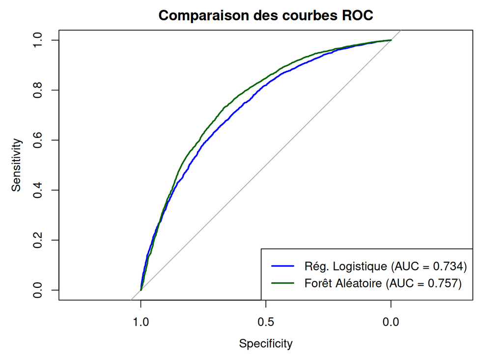

Figure 1: Comparaison des courbes ROC

```r
plot(roc_logistic, col = "blue", main = "Comparaison des courbes ROC")
plot(roc_rf, col = "darkgreen", add = TRUE)
legend("bottomright",
       legend = c(
         paste0("Rég. Logistique (AUC = ", round(auc(roc_logistic), 3), ")"),
         paste0("Forêt Aléatoire (AUC = ", round(auc(roc_rf), 3), ")")
       ),
       col = c("blue", "darkgreen"),
       lwd = 2)
```

## Validation croisée comparée

```r
resamps <- resamples(list(
  Logistique = model_logistic,
  RandomForest = model_rf
))
summary(resamps)
```

```
Call:
summary.resamples(object = resamps)

Models: Logistique, RandomForest
Number of resamples: 5

ROC
                  Min.   1st Qu.    Median      Mean   3rd Qu.      Max. NA's
Logistique   0.7264224 0.7285935 0.7345216 0.7319348 0.7347910 0.7353453    0
RandomForest 0.7418470 0.7438574 0.7486023 0.7482929 0.7487526 0.7584053    0

Sens
                  Min.   1st Qu.    Median      Mean   3rd Qu.      Max. NA's
Logistique   0.5104167 0.5419053 0.5473958 0.5404067 0.5489583 0.5533576    0
RandomForest 0.5609375 0.5770833 0.5963542 0.5894570 0.6002082 0.6127017    0

Spec
                  Min.   1st Qu.    Median      Mean   3rd Qu.      Max. NA's
Logistique   0.7786527 0.7844338 0.7860892 0.7869830 0.7895888 0.7961505    0
RandomForest 0.7567804 0.7621338 0.7891514 0.7791984 0.7930884 0.7948381    0
```

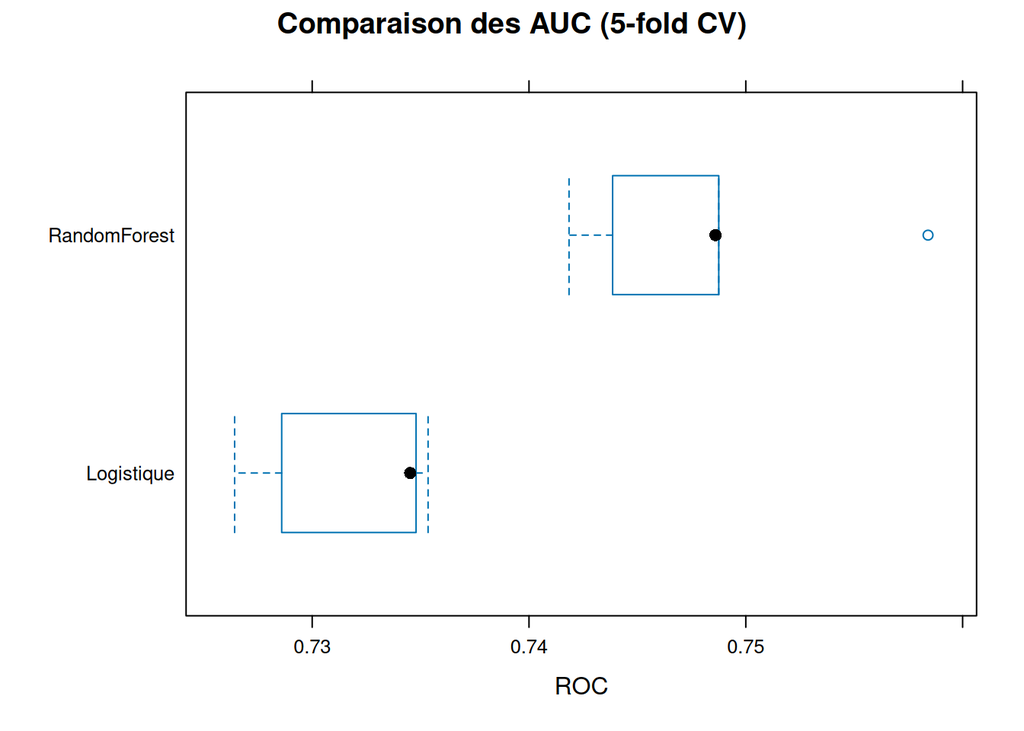

Figure 2: Comparaison des AUC par validation croisée

```r
bwplot(resamps, metric = "ROC", main = "Comparaison des AUC (5-fold CV)")
```

## Choix final et justification

```r
if (auc(roc_rf) > auc(roc_logistic)) {
  cat("Le modèle retenu est la Forêt Aléatoire.\n")
  cat("Justification : meilleure AUC sur le jeu de test, capacité à capturer\n")
  cat("les relations non-linéaires entre les notes olfactives et la satisfaction.\n")
} else {
  cat("Le modèle retenu est la Régression Logistique.\n")
  cat("Justification : performance comparable ou supérieure avec une meilleure\n")
  cat("interprétabilité des résultats.\n")
}
```

```
Le modèle retenu est la Forêt Aléatoire.
Justification : meilleure AUC sur le jeu de test, capacité à capturer
les relations non-linéaires entre les notes olfactives et la satisfaction.
```

**ImportantModèle retenu**

Le choix du modèle final repose sur la comparaison de l’AUC sur le jeu de test, combinée à l’analyse de la sensibilité, de la spécificité et du score F1. Voir la Figure 1 pour la visualisation des courbes ROC.

# Conclusion

Dans ce projet, nous avons construit un pipeline complet de classification supervisée pour prédire la satisfaction des utilisateurs vis-à-vis des parfums.

**Résumé des étapes :**

1. **Analyse exploratoire** : nous avons identifié les distributions des variables, les valeurs manquantes et les relations avec la variable cible.
2. **Feature engineering** : les variables textuelles (accords, notes) ont été transformées en indicatrices binaires. Des variables de comptage (nombre de notes) ont été ajoutées.
3. **Modélisation** : deux classifieurs ont été entraînés et comparés :
   - La **régression logistique** avec régularisation Elastic Net offre un modèle interprétable (Zou et Hastie 2005).
   - La **forêt aléatoire** capture les interactions non-linéaires entre variables (Breiman 2001).
4. **Évaluation** : les modèles ont été évalués par validation croisée 5-fold et sur un jeu de test indépendant (30%), en utilisant l’AUC, l’accuracy, la sensibilité et la spécificité (Kuhn 2008).

## Pistes non explorées

- **Autres classifieurs** : SVM, XGBoost, ou réseaux de neurones pourraient améliorer les performances.
- **NLP plus avancé** : un encodage TF-IDF ou des embeddings des notes olfactives pourrait mieux capturer l’information textuelle.
- **Données supplémentaires** : le nom de la marque et le parfumeur pourraient être des prédicteurs utiles après encodage adéquat.

## Références

Breiman, Leo. 2001. « Random Forests ». *Machine Learning* 45 (1): 5‑32.

Kuhn, Max. 2008. « Building Predictive Models in R Using the caret Package ». *Journal of Statistical Software* 28 (5).

Zou, Hui, et Trevor Hastie. 2005. « Regularization and Variable Selection via the Elastic Net ». *Journal of the Royal Statistical Society: Series B* 67 (2): 301‑20.